# Bayes Factor Design Analysis

Author

Stefano Dalla Bona

# 1. BFDA

We conduct a design analysis to determine the necessary sample size for testing whether exposure to a foreign language can reduce the illusion of causality. Our primary hypothesis centers on the difference between two groups: one group using their native language (NL) and the other using a foreign language (FL). We aim to apply Bayesian inference to evaluate evidence for either $H_0$ (no difference between the two groups) or $H_1$ (the FL reduces the illusion), and to estimate a credible interval for the effect size (ES) through the posterior distribution.

To achieve this, the Bayes Factor appears to be the most appropriate method. For this reason, our design analysis will be based on the Bayes Factor Design Analysis (BFDA). This approach is well outlined in two key articles by [Schönbrodt and Wagenmakers (2016)](https://osf.io/preprints/osf/d4dcu) and [Stefan et al. (2017)](https://osf.io/preprints/psyarxiv/aqr79), which provide a comprehensive tutorial on BFDA.

## 1.1 Bayes Factor

The **Bayes Factor** (BF; [Jeffreys, 1935](https://doi.org/10.1017/S030500410001330X)) is a statistical measure that quantifies the strength of evidence for one hypothesis over another. It is mathematically defined as the ratio of the marginal likelihoods of the data under the alternative hypothesis ($H_1$) and the null hypothesis ($H_0$):

$$BF_{10} = \frac{p(D|H_1)}{p(D|H_0)}$$

Where:

- $p(D|H_1)$ is the likelihood of the data under the **alternative hypothesis** ($H_1$).
- $p(D|H_0)$ is the likelihood of the data under the **null hypothesis** ($H_0$).

If the null hypothesis ($H_0$) and the alternative hypothesis ($H_1$) are considered equally probable a priori (i.e., $p(H_1) = p(H_0) = 0.5$), then a BF of $BF_{10} = 6$ would indicate that the data are 6 times more likely under the alternative hypothesis ($H_1$) than under the null hypothesis ($H_0$). This would correspond to a posterior probability of 86% for $H_1$ and 14% for $H_0$ [(Stefan et al., 2017)](https://osf.io/preprints/psyarxiv/aqr79).

The Bayes Factor is particularly useful in hypothesis testing, as it quantifies evidence in favor of both hypotheses ($H_0$ and $H_1$) – a feature not provided by traditional Null Hypothesis Significance Testing (NHST). In our context, where we are interested in determining whether the foreign language effect (FLE) influences the illusion of causality, the BF offers a significant advantage over classical testing approaches.

### 1.1.1 Decision Rules for Bayes Factor

Decision rules for supporting either $H_0$ or $H_1$ often involve specifying upper and lower thresholds for the BF. Specifically:

- If the BF exceeds the upper threshold, it is considered evidence for the alternative hypothesis ($H_1$).
- If the BF falls below the lower threshold, it is considered evidence for the null hypothesis ($H_0$).
- If the BF lies between these thresholds, the evidence is considered inconclusive.

### 1.1.2 Interpretation of Bayes Factors

Several researchers have proposed heuristic classification schemes for interpreting BF. Below is a rough scale for interpreting $BF_{10}$, adapted from [Lee & Wagenmakers, 2013](https://bpb-us-e2.wpmucdn.com/faculty.sites.uci.edu/dist/0/180/files/2011/03/BB_Free.pdf):

| **Bayes Factor (BF₁₀)** | **Evidence Category** |
| --- | --- |
| $> 100$ | Extreme evidence for $H_1$ |
| $30 - 100$ | Very strong evidence for $H_1$ |
| $10 - 30$ | Strong evidence for $H_1$ |
| $3 - 10$ | Moderate evidence for $H_1$ |
| $1 - 3$ | Anecdotal evidence for $H_1$ |
| $1$ | No evidence |
| $\frac{1}{3} - 1$ | Anecdotal evidence for $H_0$ |
| $\frac{1}{10} - \frac{1}{3}$ | Moderate evidence for $H_0$ |
| $\frac{1}{30} - \frac{1}{10}$ | Strong evidence for $H_0$ |
| $\frac{1}{100} - \frac{1}{30}$ | Very strong evidence for $H_0$ |
| $< \frac{1}{100}$ | Extreme evidence for $H_0$ |

This classification provides a helpful guide for interpreting the strength of evidence in favor of either $H_1$ or $H_0$ based on the observed BF.

## 1.2 Another Perspective on Power

In the traditional NHST framework, power analysis is used to estimate the probability of correctly rejecting the null hypothesis, based on a point estimate of the effect size under the alternative hypothesis. This analysis is useful for determining the required sample size to detect an effect, assuming that the effect size is known in advance.

In contrast, Bayesian Design Analysis has a different objective. Rather than focusing on the likelihood of rejecting the null hypothesis, the aim is to estimate the precision of the result. Specifically, it quantifies the probability that the BF will be either conclusive or inconclusive. This approach provides a more nuanced understanding of the evidence in favor of the null or alternative hypotheses, emphasizing the strength of evidence rather than a simple binary decision.

## 1.3 Prior Distributions for BFDA

In order to perform the BFDA, we need to consider two prior distributions under $H_1$:

- The Design Prior, as defined by [Schönbrodt and Wagenmakers (2016)](https://osf.io/preprints/osf/d4dcu), is the prior used before data collection to quantify prior beliefs about the true state of nature and to assist in experimental design. Its purpose is to make compelling evidence likely and to avoid misleading evidence. The design prior incorporates our beliefs about the possible ESs, given the experimental conditions, and helps to guide the sampling process for calculating the BF. In our case, the prior distribution is the calculated distribution of Cohen’s $d$ based on our [previous simulation](https://stefanodallabona.github.io/slides/Distsimulation.html).
- The Analysis Prior is used for Bayesian statistical analysis after the data are in – that is, to compute the BF. Unlike the Design Prior, which is more informative and based on prior beliefs before data collection, the Analysis Prior should be convincing to a skeptical target audience [(Schönbrodt & Wagenmakers, 2016)](https://osf.io/preprints/osf/d4dcu). As such, the Analysis Prior is typically less informative than the Design Prior. In our case, we rely on what is known as the Objective Bayesian Prior, which has been incorporated into the JSZ function proposed by [Morey and Rouder (2024)](https://CRAN.R-project.org/package=BayesFactor). This prior suggests that the ES under $H_1$ follows a Cauchy distribution with a scale parameter of $\frac{\sqrt{2}}{2}$. This Cauchy distribution is chosen because it places 50% of the probability mass on ESs with an absolute size smaller than $\frac{\sqrt{2}}{2}$, and the remaining 50% larger than $\frac{\sqrt{2}}{2}$. This reflects a prior expectation where smaller ESs are more likely, but large ESs are still plausible, thus making the prior relatively uninformative and neutral about the magnitude of the effect. Under $H_0$, the JSZ function assumes a null point spike distribution where all mass is centered on 0.

# 2. Design Analysis

The following is an adapted version of the algorithmic model outlined by [Schönbrodt and Wagenmakers (2016)](https://osf.io/preprints/osf/d4dcu) for performing a design analysis with BF:

1. Define a population (or distributions) reflecting the expected ES under the alternative hypothesis $H_1$ (i.e., the design prior): In our case, this correspond to the situation where a true difference exists between the two populations (i.e., we are hypothesizing a meaningful difference of 10 points on a scale from 0 to 100 between the NL and FL groups).
2. Draw a random sample of size $n$ from each population: The sample size $n$ should be fixed and identical for both groups.
3. Compute the BF for simulated data: The BF will be computed using the analysis prior that will also be used in the actual data analysis. We are interested in checking if the BF exceeds a certain threshold $y$. If $BF > y$, the result is considered a “correct answer.” If $\frac{1}{y} < BF \leq y$, the result is considered “inconclusive.” If $BF < \frac{1}{y}$, the result is considered to be in the “wrong direction.”
4. Repeat the simulation (e.g., 10,000 times): Repeat steps 2 and 3 multiple times to obtain a distribution of BF values under $H_1$, for given sample sizes ($n_x, n_{x+y},..$). This allow to calculate the different types of results that may be yielded from different sample sizes.
5. Simulate data under $H_0$ for false-positive probability: Perform the same simulation process as in steps 2 and 3, but this time assume the null hypothesis $H_0$ is true (i.e., no true effect exists between the populations). This allows us to estimate the false-positive rate (i.e., the probability of incorrectly supporting $H_1$ when $H_0$ is true).

## 2.1 Under $H_1$

To compute the design prior, we define the population parameters based on the dataframe we created from the [truncated normal distribution file](https://stefanodallabona.github.io/slides/Distsimulation.html). This dataframe accounts for different combinations of a mean difference of 10 points on a bounded scale from 0 to 100. Specifically, the NL group mean ranges from 55 to 65 (with $SD = 20$), and the SD for the FL group varies between 20 and 25. We sample rows from this dataframe to run the BFDA considering different hypothesized parameters.

```r
# Load the required data
load("effect_size.Rda")

# Function to generate data from a truncated normal distribution
tnorm_f <- function(n, mean, sd, a = 0, b = 100) {
  qnorm(runif(n, pnorm(a, mean, sd), pnorm(b, mean, sd)), mean, sd)
}

# Function to run simulations
library(BayesFactor)

run_simulation <- function(n_sim = 100000, sample_size = 100) {
  BF_set <- rep(NA, n_sim)

  for(i in 1:n_sim) {
    sam <- effect_size_treatment_sd_df[sample(length(effect_size_treatment_sd_df), 1),]

    # Simulate control (NL group) and treatment (FL group) data
    control <- round(tnorm_f(n = sample_size, mean = as.numeric(sam[4]), sd = 20)) # NL group
    treat <- round(tnorm_f(n = sample_size, mean = as.numeric(sam[2]), sd = as.numeric(sam[8]))) # FL group

    # Perform BF
    result <- ttestBF(control, treat, nullInterval = c(0, Inf))

    # Store BF
    BF_set[i] <- as.data.frame(result)$bf[1]
  }

  # Classify the BF
  vector_Waffle <- rep(NA, length(BF_set))
  vector_Waffle[BF_set < 1/10] <- "Wrong Direction"
  vector_Waffle[BF_set >= 1/10 & BF_set <= 10] <- "Inconclusive"
  vector_Waffle[BF_set > 10] <- "Right Direction"

  # Return the results
  return(data.frame(BF = BF_set, direction = as.factor(vector_Waffle)))
}

# Simulations for each sample size
sample_sizes <- c(40, 50, 60, 70, 80, 90, 100, 110, 120, 130)
simulation_results <- list()


for (size in sample_sizes) {
  sim_result <- run_simulation(n_sim = 100000, sample_size = size)
  sim_result$sample_size <- size
  simulation_results[[as.character(size)]] <- sim_result
}

# Combine all the results
all_results <- do.call(rbind, simulation_results)
```

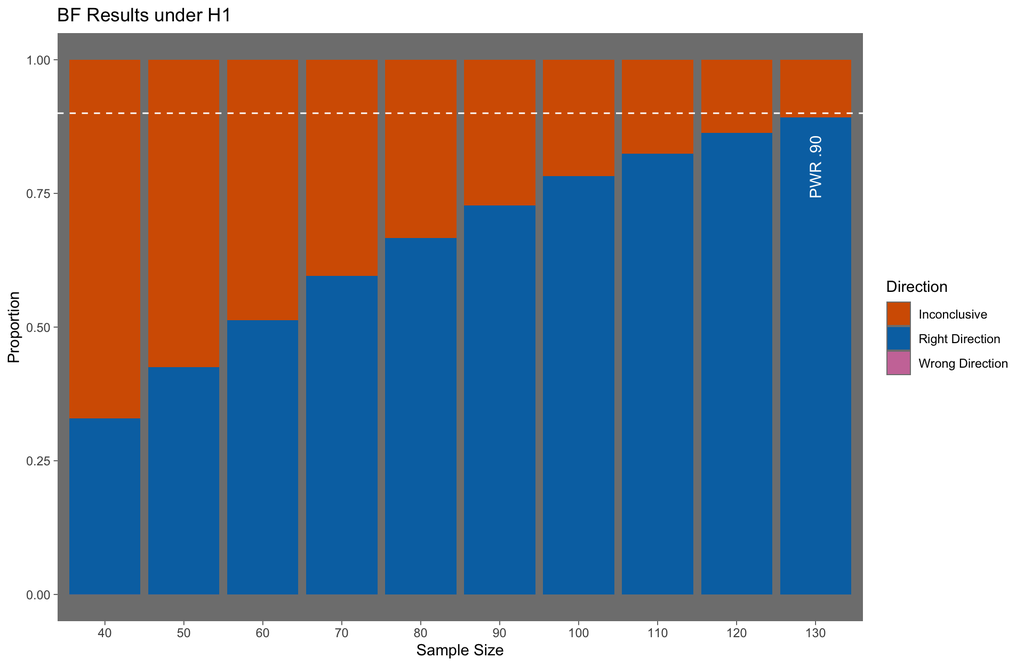

```r
# Plot the results
library(ggplot2); library(ggokabeito)

PWR <- ggplot(all_results, aes(x = factor(sample_size), fill = direction)) +
  scale_fill_okabe_ito(order = c(6, 5, 7)) +
  geom_bar(position = "fill") +
  labs(title = "BF Results under H1",
       x = "Sample Size",
       y = "Proportion",
       fill = "Direction") +
  geom_hline(yintercept = .9, lty = "dashed", col = "white") +
  theme_dark() + theme(panel.grid.major = element_blank(),
                       panel.grid.minor = element_blank()) +
  annotate("text", x = 10, y = 0.8, label = "PWR .90", angle = '90', col = "white")

PWR
```

```r
# Print the contingency table of directions and sample sizes
table(all_results$direction, all_results$sample_size) / 1000
```

```
                      40     50     60     70     80     90    100    110
  Inconclusive    67.033 57.511 48.688 40.467 33.349 27.278 21.757 17.600
  Right Direction 32.953 42.480 51.308 59.526 66.649 72.721 78.242 82.398
  Wrong Direction  0.014  0.009  0.004  0.007  0.002  0.001  0.001  0.002

                     120    130
  Inconclusive    13.664 10.829
  Right Direction 86.334 89.171
  Wrong Direction  0.002  0.000
```

## 2.2 Under $H_0$

We perform the same simulation process as in the previous section, but now we assume $H_0$ is true. This allows us to compute the false positive rate – the probability of incorrectly supporting $H_1$ when no true effect exists. We expect the false positive rate to be less than 1% for 100 participants per group.

```r
# Function to compute false positive rate
run_simulation <- function(n_sim = 100000, sample_size = 100) {
  BF_set <- rep(NA, n_sim)

  for(i in 1:n_sim) {
    sam <- effect_size_treatment_sd_df[sample(length(effect_size_treatment_sd_df), 1),]

    # Generate data for both groups under H0
    control <- round(tnorm_f(n = sample_size, mean = as.numeric(sam[4]), sd = 20)) # NL group
    treat <- round(tnorm_f(n = sample_size, mean = as.numeric(sam[4]), sd = 20)) # NL == FL group

    # Perform BF
    result <- ttestBF(control, treat, nullInterval = c(0, Inf))

    # Store BF
    BF_set[i] <- as.data.frame(result)$bf[1]
  }

  # Classify BF
  vector_Waffle <- rep(NA, length(BF_set))

  vector_Waffle[BF_set < 1/10] <- "Right Direction"
  vector_Waffle[BF_set >= 1/10 & BF_set <= 10] <- "Inconclusive"
  vector_Waffle[BF_set > 10] <- "False Positive"  # False positive when BF > 6

  # Return the results
  return(data.frame(BF = BF_set, direction = as.factor(vector_Waffle)))
}

# Run the simulation for different sample sizes
sample_sizes <- c(40, 50, 60, 70, 80, 90, 100, 110, 120, 130)
simulation_results <- list()

for (size in sample_sizes) {
  sim_result <- run_simulation(n_sim = 100000, sample_size = size)
  sim_result$sample_size <- size
  simulation_results[[as.character(size)]] <- sim_result
}

# Combine all the results
all_results <- do.call(rbind, simulation_results)
```

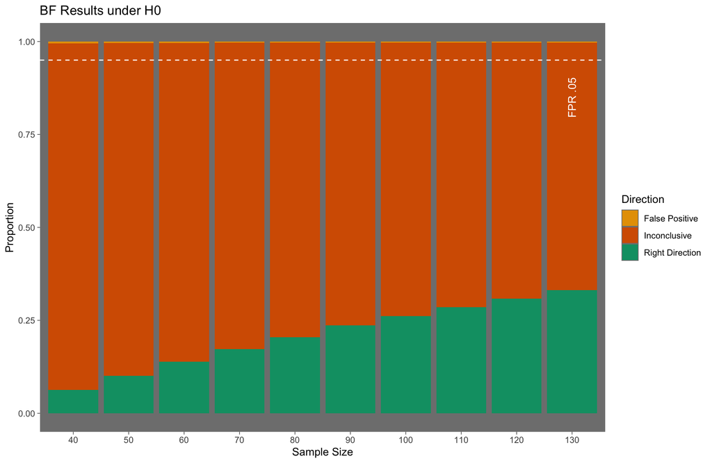

```r
# Plot the results
FPR <- ggplot(all_results, aes(x = factor(sample_size), fill = direction)) +
  scale_fill_okabe_ito(order = c(1, 6, 3)) +
  geom_bar(position = "fill") +
  labs(title = "BF Results under H0",
       x = "Sample Size",
       y = "Proportion",
       fill = "Direction") +
  theme_dark() +
  theme(panel.grid.major = element_blank(),
        panel.grid.minor = element_blank()) +
  geom_hline(yintercept = .95, lty = "dashed", col = "white") +
  annotate("text", x = 10, y = 0.85, label = "FPR .05",
           angle = '90', col = "white")
FPR
```

```r
# Print contingency table for the direction of BF
table(all_results$direction, all_results$sample_size) / 1000
```

```
                      40     50     60     70     80     90    100    110
  False Positive   0.474  0.384  0.366  0.354  0.345  0.350  0.344  0.325
  Inconclusive    93.207 89.585 85.794 82.392 79.217 75.959 73.560 71.114
  Right Direction  6.319 10.031 13.840 17.254 20.438 23.691 26.096 28.561

                     120    130
  False Positive   0.322  0.291
  Inconclusive    68.883 66.572
  Right Direction 30.795 33.137
```

## 2.3 BFDA Package

To check for consistency in the results obtained with the BFDA method, we can use the [`BFDA`](https://github.com/nicebread/BFDA) package. This allows us to input only the ES vector and perform the same analysis. Below, we re-perform the same analysis with the `BFDA` package and we confirm previous findings.

```r
# Simulate under H1
library(BFDA)

sim.H1 <- BFDA.sim(
  expected.ES = effect_size_treatment_sd_df$d,
  type = "t.between",
  prior = list("Cauchy", list(prior.location = 0, prior.scale = sqrt(2)/2)),
  alternative = "greater",
  B = 1000,
  verbose = F,
  cores = 4,
  stepsize = 10
)

# Simulate under H0
sim.H0 <- BFDA.sim(
  expected.ES = 0,
  type = "t.between",
  prior = list("Cauchy", list(prior.location = 0, prior.scale = sqrt(2)/2)),
  n.min = 20,
  n.max = 300,
  alternative = "greater",
  boundary = Inf,
  B = 1000,
  verbose = F,
  cores = 4,
  stepsize = 10
)

# Analyze simulation results for H1
BFDA.analyze(sim.H1, design = "fixed", n = 100, boundary = 10)
```

```
78.2% showed evidence for H1 (BF > 10)
21.8% were inconclusive (0.1 < BF < 10)
0% showed evidence for H0 (BF < 0.1)
```

```
Sample size determination for a fixed-n design:
---------------------------------------

A >= 90% (actual: 91%) power achieved at n = 130
This setting implies long-term rates of:
9% inconclusive results and
   0% false-negative results.
```

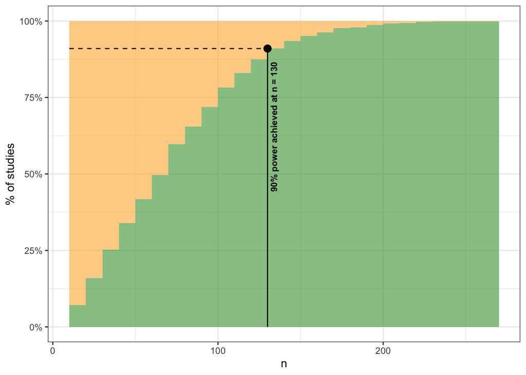

```r
# Estimate the sample size required for 80% power with a compelling evidence threshold of 6
SSD(sim.H1, power = .90, boundary = c(1/10, 10))
```

```
Sample size determination for a fixed-n design:
---------------------------------------

A >= 2% (actual: 0.5%) long-term rate of Type-I errors is achieved at n = 20
This setting implies long-term rates of:
98.8% inconclusive results and
   0.7% true-negative results.
```

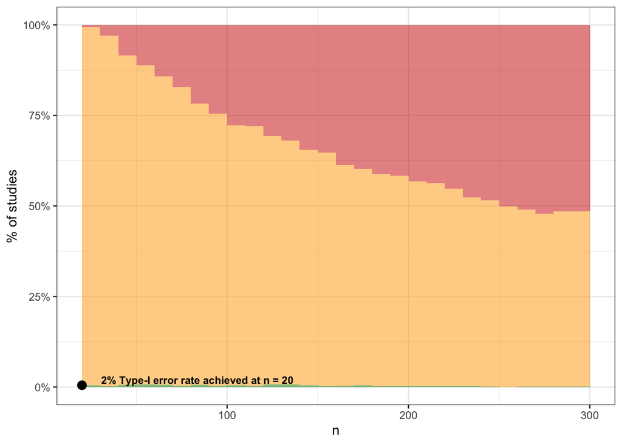

```r
# Estimate the false-positive rate
SSD(sim.H0, alpha = .02, boundary = c(1/10, 10))
```

# 3. References

- Barrett, M. (2024). *ggokabeito: ‘Okabe-Ito’ Scales for ‘ggplot2’ and ‘ggraph’*. R package version 0.1.0.9000, commit e28e8b7a0a3301ac40722fb07ed082bde424bb8f, https://github.com/malcolmbarrett/ggokabeito.
- Lee, M. D., Wagenmakers, E.-J. (2014).Bayesian cognitive modeling: A practical course. Cambridge University Press.
- Jeffreys, H. (1935). Some tests of significance, treated by the theory of probability. In *Mathematical proceedings of the Cambridge philosophical society* (Vol. 31, No. 2, pp. 203-222). Cambridge University Press. https://doi.org/10.1017/S030500410001330X
- Morey, R., Rouder, J. (2024). *BayesFactor: Computation of Bayes Factors for Common Designs*. R package version 0.9.12-4.7, https://CRAN.R-project.org/package=BayesFactor.
- Schönbrodt, F. D., Wagenmakers, E. (2016). Bayes Factor Design Analysis: Planning for compelling evidence. https://doi.org/10.3758/s13423-017-1230-y
- Schönbrodt, F. D., Stefan, A. M. (2019). BFDA: An R package for Bayes factor design analysis (version 0.5.0). Retrieved from https://github.com/nicebread/BFDA
- Stefan, A. M., Gronau, Q. F., Schönbrodt, F. D., & Wagenmakers, E. (2017). A Tutorial on Bayes Factor Design Analysis Using an Informed Prior. https://doi.org/10.3758/s13428-018-01189-8
- Wickham, H. (2016). ggplot2: Elegant Graphics for Data Analysis. Springer-Verlag New York.